# Two-Sample Tests: Lecture Notes

Parametric and Nonparametric Methods

Author

Jyotishka Datta

Published

April 2, 2026

# 1 Overview

These notes accompany the lecture slides on **Two-Sample Tests**. The goal is to compare two independent populations — either their means (location) or their spreads (scale) — using both parametric and nonparametric approaches.

We cover:

- Two-sample $t$-tests and the Behrens-Fisher problem
- Permutation test
- Wilcoxon rank-sum / Mann-Whitney $U$ test
- Asymptotic Relative Efficiency
- Hodges-Lehmann estimator
- Scale tests ($F$-test, Siegel-Tukey)
- $Q$-$Q$ plots and the Kolmogorov-Smirnov test
- A brief look at Difference-in-Differences as an application

# 2 The Location-Scale Family (Interactive)

Before diving into tests, let’s build intuition about **location** and **scale** shifts.

A **location shift** moves the distribution left/right (changes the mean/median).  
A **scale shift** stretches or shrinks the distribution (changes the variance).

The interactive figure below lets you explore both simultaneously. Drag the sliders to see how $N(\mu, \sigma^2)$ changes.

[interactive chart not shown]

Location shift Δ (red curve) Δ = 0

Scale factor σ (red curve) σ = 1

**Blue:** N(0,1) reference | **Red:** N(Δ, σ²) | A location shift slides the curve; a scale shift stretches it.

**Key observations:**

- When $\Delta \ne 0$ and $\sigma = 1$: pure **location shift** — curves identical in shape, just shifted
- When $\Delta = 0$ and $\sigma \ne 1$: pure **scale shift** — curves centered at the same point but different spread
- Both together: the red $N(\Delta, \sigma^2)$ curve is shifted and re-scaled relative to the blue $N(0,1)$ curve

# 3 Two-Sample $t$-test

## 3.1 Motivating Example: Birth-weight Data

We use the `births14` dataset from OpenIntro, a random sample of 1,000 US births from 2014.

```r
birth <- read.csv("https://www.openintro.org/data/csv/births14.csv")
dim(birth)
```

```
[1] 1000   13
```

```r
# Keep only complete cases (no missing values)
birth <- birth[complete.cases(birth), ]
```

It is always a good idea to inspect the structure of the data before doing any analysis:

```r
str(birth)
```

```
'data.frame':   794 obs. of  13 variables:
 $ fage          : int  34 36 37 32 32 37 29 30 29 30 ...
 $ mage          : int  34 31 36 31 26 36 24 32 26 34 ...
 $ mature        : chr  "younger mom" "younger mom" "mature mom" "younger mom" ...
 $ weeks         : int  37 41 37 36 39 36 40 39 39 42 ...
 $ premie        : chr  "full term" "full term" "full term" "premie" ...
 $ visits        : int  14 12 10 12 14 10 13 15 11 14 ...
 $ gained        : int  28 41 28 48 45 20 65 25 22 40 ...
 $ weight        : num  6.96 8.86 7.51 6.75 6.69 6.13 6.74 8.94 9.12 8.91 ...
 $ lowbirthweight: chr  "not low" "not low" "not low" "not low" ...
 $ sex           : chr  "male" "female" "female" "female" ...
 $ habit         : chr  "nonsmoker" "nonsmoker" "nonsmoker" "nonsmoker" ...
 $ marital       : chr  "married" "married" "married" "married" ...
 $ whitemom      : chr  "white" "white" "not white" "white" ...
```

**Research question 1:** Is mean birth weight the same for smokers and nonsmokers?

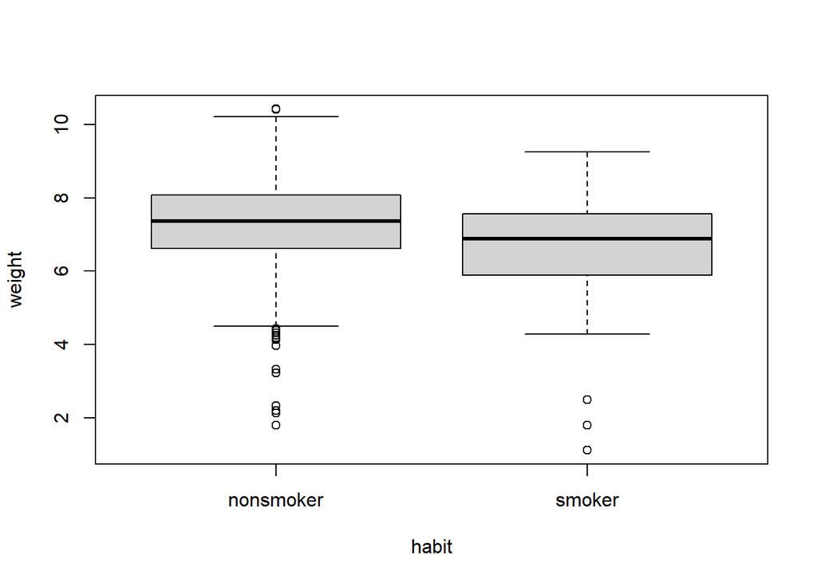

```r
boxplot(weight ~ habit, data = birth)
```

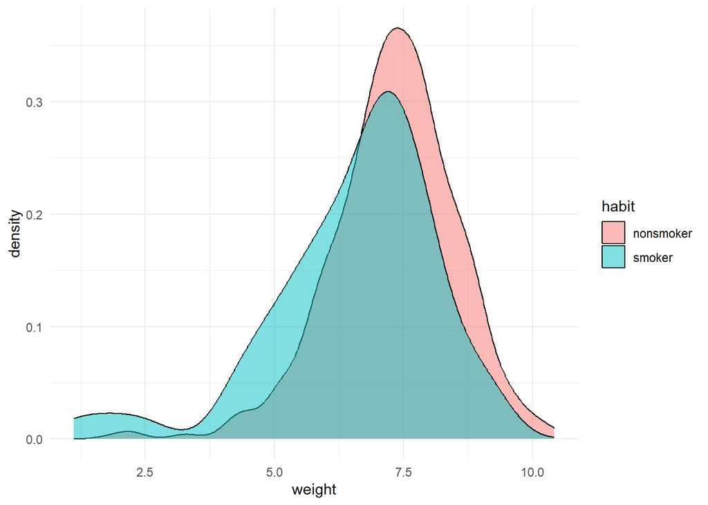

```r
library(ggplot2)
ggplot(birth, aes(x = weight, group = habit, fill = habit)) +
  geom_density(alpha = 0.5) + theme_minimal()
```

Now, let’s see how the tests perform on this data set. We will look at the equal variance and the unequal variance case, and use both the R built-in function as well as manual calculation. The point of manual calculation is to show that you could do the exact same test with the formuale available, even if the built-in function did not exist.

### 3.1.1 Equal Variance $t$-test

Under $H_0: \mu_X = \mu_Y$, if we assume **equal variances** $\sigma_X^2 = \sigma_Y^2 = \sigma^2$, the test statistic is:

$$T = \frac{\bar{X} - \bar{Y}}{S_p \sqrt{1/m + 1/n}} \sim t_{m+n-2}$$

The **pooled standard deviation** $S_p$ combines information from both samples:

$$S_p = \sqrt{\frac{(m-1)S_X^2 + (n-1)S_Y^2}{m+n-2}}$$

```r
x <- birth$weight[birth$habit == "nonsmoker"]
y <- birth$weight[birth$habit == "smoker"]

t.test(x, y, alternative = "greater", var.equal = TRUE)
```

```
    Two Sample t-test

data:  x and y
t = 4.5821, df = 792, p-value = 2.672e-06
alternative hypothesis: true difference in means is greater than 0
95 percent confidence interval:
 0.4817562       Inf
sample estimates:
mean of x mean of y
 7.306544  6.554516
```

You can also use the **formula interface** — convenient when the data are in a data frame:

```r
t.test(weight ~ habit, data = birth,
       alternative = "greater", var.equal = TRUE)
```

```
    Two Sample t-test

data:  weight by habit
t = 4.5821, df = 792, p-value = 2.672e-06
alternative hypothesis: true difference in means between group nonsmoker and group smoker is greater than 0
95 percent confidence interval:
 0.4817562       Inf
sample estimates:
mean in group nonsmoker    mean in group smoker
               7.306544                6.554516
```

Both calls produce identical output. The $p$-value is extremely small ($p < 0.0001$), giving strong evidence that nonsmokers have higher birth-weight babies.

#### 3.1.1.1 Manual calculation

```r
s1 <- sd(x);  s2 <- sd(y)
m  <- length(x);  n <- length(y)
ntotal <- m + n

# Pooled standard deviation
spooled <- sqrt(((m-1)*(s1^2) + (n-1)*(s2^2))) / sqrt(ntotal - 2)

# t-statistic
tval <- (mean(x) - mean(y)) / (spooled * sqrt(1/m + 1/n))
tval
```

```
[1] 4.58215
```

```r
## [1] 4.58215

# One-sided p-value: P(T > tval) under t_{m+n-2}
(pval <- 1 - pt(tval, df = ntotal - 2))
```

```
[1] 2.672421e-06
```

```r
## [1] 2.672421e-06
```

### 3.1.2 Unequal Variance (Welch) $t$-test

If $\sigma_X^2 \ne \sigma_Y^2$, Welch’s test uses a different denominator:

$$T_W = \frac{\bar{X} - \bar{Y}}{\sqrt{S_X^2/m + S_Y^2/n}}$$

The degrees of freedom $\nu$ are estimated by the **Satterthwaite approximation**:

$$\nu = \frac{\left(S_X^2/m + S_Y^2/n\right)^2}{\dfrac{\left(S_X^2/m\right)^2}{m-1} + \dfrac{\left(S_Y^2/n\right)^2}{n-1}}$$

```r
t.test(x, y, alternative = "greater", var.equal = FALSE)
```

```
    Welch Two Sample t-test

data:  x and y
t = 3.5993, df = 66.935, p-value = 0.0003033
alternative hypothesis: true difference in means is greater than 0
95 percent confidence interval:
 0.4035308       Inf
sample estimates:
mean of x mean of y
 7.306544  6.554516
```

[output not shown]

Notice the $df$ dropped from 792 to $\approx 67$ because the smoker group is much smaller.

#### 3.1.2.1 Manual calculation (unequal variance)

```r
s1 <- sd(x);  s2 <- sd(y)
m  <- length(x);  n <- length(y)

tval <- (mean(x) - mean(y)) / sqrt(s1^2/m + s2^2/n)
tval
```

```
[1] 3.599276
```

```r
## [1] 3.599276

(df <- (s1^2/m + s2^2/n)^2 /
        (1/(m-1) * (s1^2/m)^2 + 1/(n-1) * (s2^2/n)^2))
```

```
[1] 66.93501
```

```r
## [1] 66.93501

(pval <- 1 - pt(tval, df = df))
```

```
[1] 0.0003032835
```

```r
## [1] 0.0003032835
```

## 3.2 The Behrens-Fisher Problem

**NoteWhat is the Behrens-Fisher Problem?**

Testing $H_0: \mu_X = \mu_Y$ when $X_i \overset{iid}{\sim} N(\mu_X, \sigma_X^2)$ and $Y_j \overset{iid}{\sim} N(\mu_Y, \sigma_Y^2)$ with $\sigma_X^2 \ne \sigma_Y^2$ — all parameters unknown — has no exact finite-sample solution. This is the Behrens-Fisher problem.

- The **equal-variance $t$-test** has an exact $t_{m+n-2}$ distribution but is **wrong** when $\sigma_X^2 \ne \sigma_Y^2$
- **Welch’s test** is a widely accepted approximate solution
- For a beginner’s course: **use `var.equal = FALSE` (Welch) as your default** — it performs nearly as well when variances are equal, and protects you when they are not

|  | Equal Var $t$ | Welch $t$ |
| --- | --- | --- |
| $t$ statistic | 4.582 | 3.599 |
| $df$ | 792 | **66.9** |
| $p$-value | $2.67 \times 10^{-6}$ | $3.03 \times 10^{-4}$ |

## 3.3 Exercise

1. Test if there is any difference in birth weights for **male and female** born babies. The boxplot and density plots are given below. Does your output match your intuition when you look at the plots?
2. Test if the weights follow a $N(\mu, \sigma^2)$ distribution.

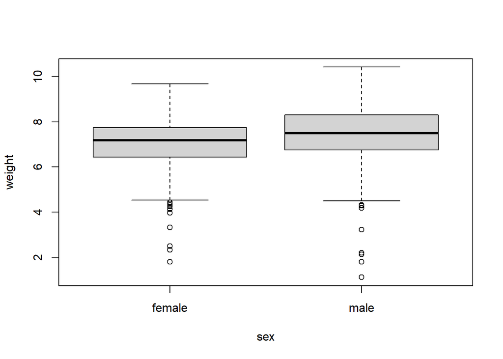

```r
boxplot(weight ~ sex, data = birth)
```

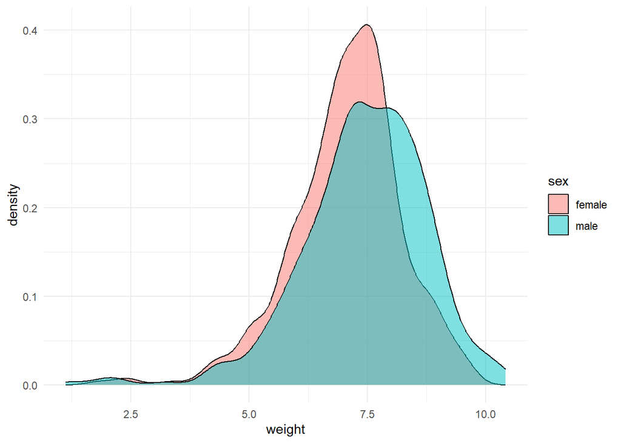

```r
ggplot(birth, aes(x = weight, group = sex, fill = sex)) +
  geom_density(alpha = 0.5) + theme_minimal()
```